# R exercise: Week 03 in Genome Analysis and Statistics

Thomas Bataillon

Time Stamp last update: 2022-02-16

# Goals of the session

The main objective for this week is to “practice in R” the central topics that you read about in chapter 4

1. Doing in R the visualization and stats on gene length dataset (example 4.1)
2. Getting some experience with manipulating data stored in R
3. Simulate sampling data from the human gene length distribution and
4. Exploring how much sample statistics reflect the properties of the population sampled
5. Visualizing a sampling distribution
6. Checking that the SE calculated with one sample is actually a good guess for the SD of the sampling distribution

# Exercise: Calculating summary statistics and SE around the mean in a sample

Here you will redo exercise 4.1 using pen and paper and R

> Q1 Make a vector called that contains the observations given in the practice exercise 4.1 of the book

Name this vector `myvector`

```r
myvector <- c(112, 128, 108, 129, 125, 153, 155, 132, 137)

sd(myvector)
```

```
## [1] 15.95306
```

```r
length(myvector)
```

```
## [1] 9
```

> Q2 use R functions to calculate the SE around the mean

```r
SE <- sd(myvector) / sqrt(length(myvector))
low <- mean(myvector) - 2 * SE
high <- mean(myvector) + 2 * SE

low
```

```
## [1] 120.3646
```

```r
high
```

```
## [1] 141.6354
```

Hints: * if you struggle here go back to week02 R sessions and calculations on vectors  
* `mean()` `length()` and `sd()` are handy check them out e.g type in the console `> ?sd()`

# Working in R on the gene length dataset (BOOK example 4.1)

Here we go through the basic motions of what data analysis typically looks like:

- We import the data in R (here the data is stored in the text file chap04e1HumanGeneLengths.csv )
- Get an overview of the data
- Calculate some statistics on the data
- Vizualize aspects fo the data

For importing the dataset, we use the R function read_csv(file = ” …“), where”…” is a **path** to the file where the data is stored.

```r
library(tidyverse)
# dfHumanGenes <- read_csv(file = "../abd_data/chapter04/chap04e1HumanGeneLengths.csv") # you may need to change this
# saveRDS(dfHumanGenes, file = "dfHumanGenes.rds") #
dfHumanGenes <- readRDS("dfHumanGenes.rds")
head(dfHumanGenes)
```

```
## # A tibble: 6 x 1
##   geneLength
##        <dbl>
## 1       2069
## 2       1303
## 3       1067
## 4       2849
## 5       3378
## 6       2391
```

```r
# summary(dfHumanGenes)
# dim(dfHumanGenes)
```

> Q3: Summarise the data by using the dim() and summary() function

```r
dim(dfHumanGenes)
```

```
## [1] 20290     1
```

```r
length(dfHumanGenes)
```

```
## [1] 1
```

```r
summary(dfHumanGenes)
```

```
##    geneLength
##  Min.   :   60
##  1st Qu.: 1312
##  Median : 2226
##  Mean   : 2622
##  3rd Qu.: 3444
##  Max.   :99631
```

- What is dim() doing in the code chunk above? # the number of data-points / “size of data”
- What is the sample size of the data? # 20290
- What is the mean and the median gene length in the human genome ? # mean=2622, median =2226
- What is the SD of the gene length ?

```r
sd(dfHumanGenes$geneLength)
```

```
## [1] 2036.967
```

- What proportion of genes are at least 5000 nucleotides long ?

```r
(sum(dfHumanGenes$geneLength > 5000) / length(dfHumanGenes$geneLength)) * 100
```

```
## [1] 9.743716
```

```r
(sum(dfHumanGenes$geneLength > 5000) / dim(dfHumanGenes$geneLength)) * 100
```

```
## numeric(0)
```

> Q4: use ggplot() to reproduce in R the Figure 4.1-1

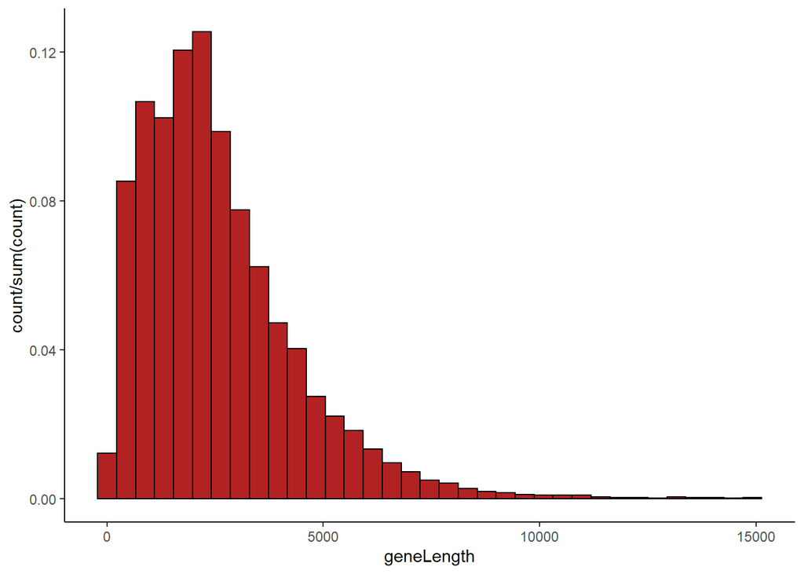

```r
dfHumanGenes %>%
    filter(geneLength < 15000) %>%
    ggplot(aes(x = geneLength)) +
    geom_histogram(aes(y = stat(count) / sum(count)), bins = 35, fill = "firebrick", color = "black") + # nolint
    theme_classic()
```

Here is the basic code for a histogram :

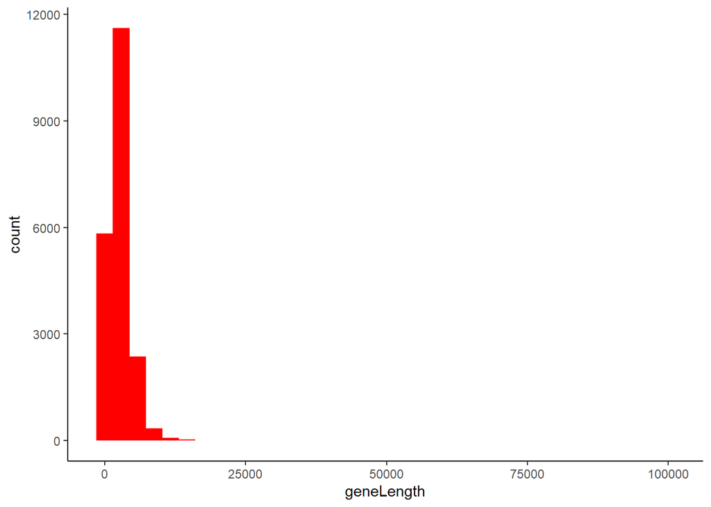

```r
# plotting all the data
# filter(dfHumanGenes, geneLength<230)
ggplot(dfHumanGenes, aes(x = geneLength)) +
    geom_histogram(bins = 35, fill = "red") +
    theme_classic() +
    NULL
```

The graph looks pretty “ugly” because it is squeezed on the left.

So try to better graphs :) that look like the book figure.

- Hint1 use filter() in the tidyverse to get rid of the observations with very high values that are “squeezing the graph”
- Hint2 use geom_histogram(bins = 35) if you want 35 bins …or fewer bins

> Q5: Generate a sample of 100 observations from the whole gene length “population”

```r
MySample100 <- sample(dfHumanGenes$geneLength, size = 100, replace = T) # adapt
mean(MySample100) # you should get a mean somewhat near the true mean
```

```
## [1] 2487.13
```

```r
mean(dfHumanGenes$geneLength)
```

```
## [1] 2622.027
```

Adapt the R function sample() in the R chunk sketched below to draw at random 100 observations from the gene length data and store these in MySample100.

Hint: look at the help for the sample() function and discuss with your TA what type of sampling can be implemented in sample(): with or without replacement ? Try and evaluate the code your wrote a couple of times: you should get a sightly different answer each time.

```r
MySample100 <- sample(x = c(0, 1, 2, 3), size = 2, replace = T) # adapt
mean(MySample100) # you should get a mean somewhat near the true mean
```

```
## [1] 1.5
```

> Q6: More challenging level 1: redo the sampling distribution of the book (Fig 4.1-3)

Simulates many samples of size $n=100$ from the human gene length distribution. For each sample, calculate (and store) the mean in the sample. Hint use a for() loop to do $nbSimulations=10^4$ samples and use the vector Vec_meansInSamples to store your calculations. An almost complete code chunk template that does just that is provided below:

```r
samplesizevector <- function(SSize) {
    nbSimulations <- 10^4 # how many samples do we use to get a sampling
    Vec_meansInSamples <- rep(NA, nbSimulations) # an empty vector to store the observed means
    # print(Vec_meansInSamples)
    for (i in 1:nbSimulations) {
        Vec_meansInSamples[i] <- mean(sample(dfHumanGenes$geneLength, size = SSize, replace = T))
    }
    Vec_meansInSamples
}
```

```r
summary(samplesizevector(100))
```

```
##    Min. 1st Qu.  Median    Mean 3rd Qu.    Max.
##    1947    2486    2609    2622    2746    4159
```

```r
summary(samplesizevector(1000))
```

```
##    Min. 1st Qu.  Median    Mean 3rd Qu.    Max.
##    2404    2579    2620    2622    2664    2928
```

> Q7: Challenging level 2: examine what happens with varying sample size

Adapt the code you wrote above and redo the extended version of the figure 4.1-4. Examine 4 sample size “scenarios” for illustration: n= 10, 30, 100, or 300.

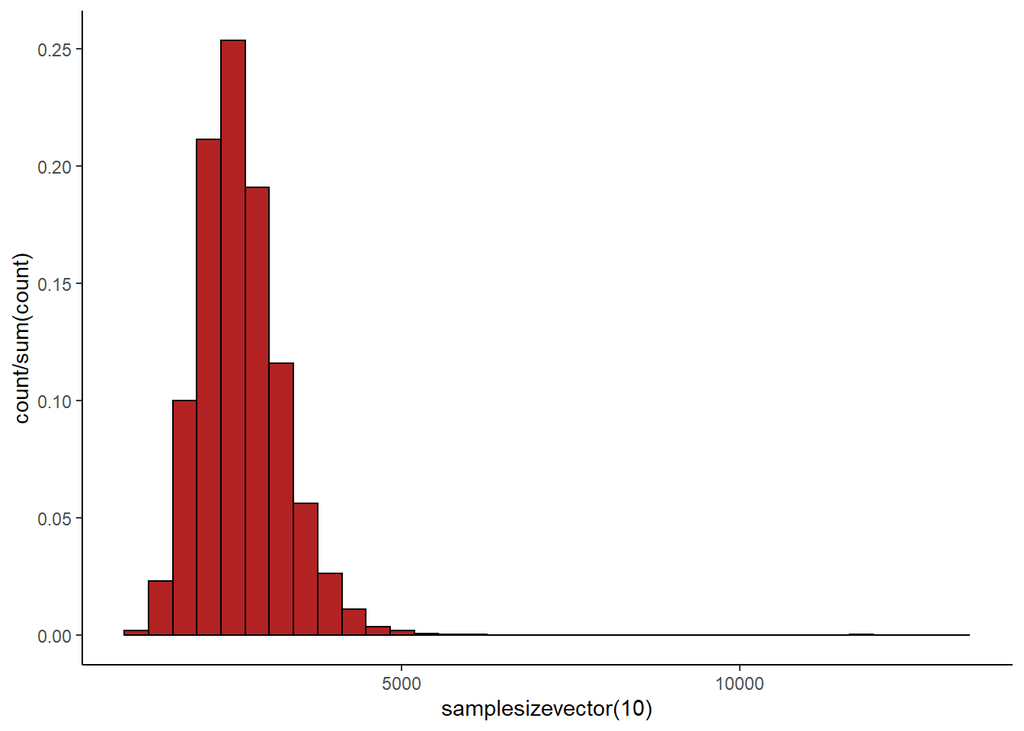

```r
ggplot() +
    geom_histogram(aes(samplesizevector(10), y = stat(count) / sum(count)), bins = 35, fill = "firebrick", color = "black") +
    theme_classic()
```

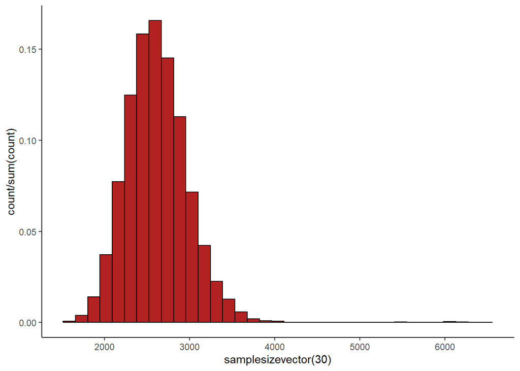

```r
ggplot() +
    geom_histogram(aes(samplesizevector(30), y = stat(count) / sum(count)), bins = 35, fill = "firebrick", color = "black") +
    theme_classic()
```

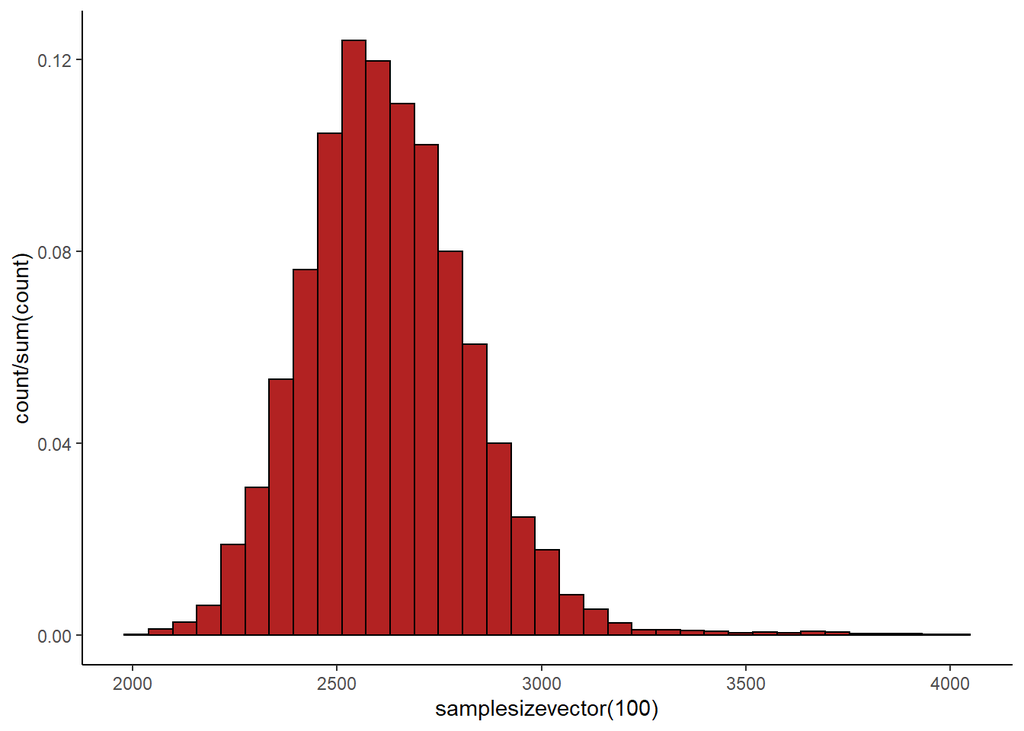

```r
ggplot() +
    geom_histogram(aes(samplesizevector(100), y = stat(count) / sum(count)), bins = 35, fill = "firebrick", color = "black") +
    theme_classic()
```

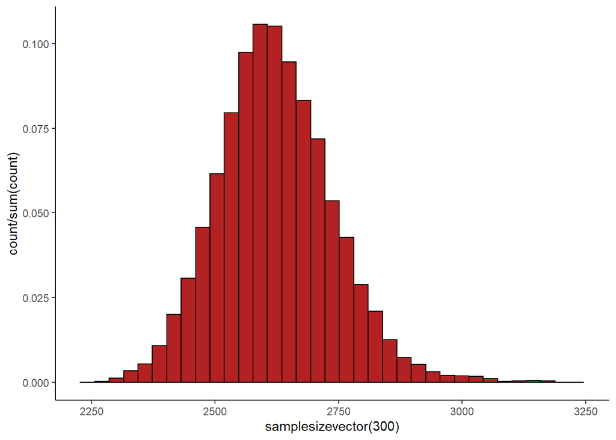

```r
ggplot() +
    geom_histogram(aes(samplesizevector(300), y = stat(count) / sum(count)), bins = 35, fill = "firebrick", color = "black") +
    theme_classic()
```

> The last Q: How often does a confidence interval “covers” the true mean ?

```r
SEM <- function(sample) {
    return(sd(sample) / sqrt(length(sample)))
}

sampleinconf <- function(SSize) {
    TrueMean <- mean(dfHumanGenes$geneLength)
    nbSimulations <- 10^4 # how many samples do we use to get a sampling
    Vec_meansInSamples <- rep(NA, nbSimulations) # an empty vector to store th

    for (i in 1:nbSimulations) {
        samplevar <- sample(dfHumanGenes$geneLength, size = SSize, replace = T)

        if (TrueMean < mean(samplevar) + 2 * SEM(samplevar) &
            TrueMean > mean(samplevar) - 2 * SEM(samplevar)) {
            Vec_meansInSamples[i] <- TRUE
        } else {
            Vec_meansInSamples[i] <- FALSE
        }
    }
    sum(Vec_meansInSamples == TRUE) / length(Vec_meansInSamples)
}
```

```r
sampleinconf(100)
```

```
## [1] 0.9458
```

A popular way to obtain a 95% confidence interval for the mean is to use observed mean +- 2SEs. Do a small simulation to see if it works:

Adapt the code you wrote for a sample size of n=100. Here we use two more vectors (VecUpper and VecLower) to store the upper limit and lower limit of each confidence interval. Calculate what proportion of the 10^4 confidence intervals you generated contain the true population mean.

# Congratulations! You did it!

You are well on your way to master the whole idea of the “pesky sampling distribution” and using effectively the tidyverse and vectors in R!